Association Rule Mining

A store is always trying to figure out which items do customers by frequently together. That way, they can either put them close together to make it convenient, put the items on opposite ends of the store to make the customers pass by the most amount of merchandise possible, or any other scheme to help raise revenue. **Association Rule Mining** tries to find those grouped items. It does this through a series of calculating the probabilites of any two items together, and then moving on a group of 3, of 4, of 5, etc., as long as the items in a group - as well as the group itself - all have probability numbers above a preset threshold.  
You would commonly analyze the grouping by finding the pairing sets within each grouping number that has the highest *confidence*, *support*, and or *lift*, which are all types of probabilites that give us different insights.  
In the analysis below, we will use a preset grocery data given to R.  
The following code creates a set of rules based on our given minimum probability values.

```r
data(Groceries)
rules <- apriori(Groceries, parameter = list(supp = .004, conf = .3, minlen=2))
```

```
## Apriori
##
## Parameter specification:
##  confidence minval smax arem  aval originalSupport maxtime support minlen
##         0.3    0.1    1 none FALSE            TRUE       5   0.004      2
##  maxlen target   ext
##      10  rules FALSE
##
## Algorithmic control:
##  filter tree heap memopt load sort verbose
##     0.1 TRUE TRUE  FALSE TRUE    2    TRUE
##
## Absolute minimum support count: 39
##
## set item appearances ...[0 item(s)] done [0.00s].
## set transactions ...[169 item(s), 9835 transaction(s)] done [0.00s].
## sorting and recoding items ... [126 item(s)] done [0.00s].
## creating transaction tree ... done [0.00s].
## checking subsets of size 1 2 3 4 5 done [0.00s].
## writing ... [735 rule(s)] done [0.00s].
## creating S4 object  ... done [0.00s].
```

And the output below is a summary of the rules’ attributes. For example, the *rule length distribution* shows how many sets of items are in each level of groups.

```r
summary(rules)
```

```
## set of 735 rules
##
## rule length distribution (lhs + rhs):sizes
##   2   3   4
## 121 516  98
##
##    Min. 1st Qu.  Median    Mean 3rd Qu.    Max.
##   2.000   3.000   3.000   2.969   3.000   4.000
##
## summary of quality measures:
##     support           confidence          lift           count
##  Min.   :0.004067   Min.   :0.3000   Min.   :1.176   Min.   : 40.00
##  1st Qu.:0.004677   1st Qu.:0.3534   1st Qu.:1.802   1st Qu.: 46.00
##  Median :0.005796   Median :0.4211   Median :2.139   Median : 57.00
##  Mean   :0.008004   Mean   :0.4339   Mean   :2.227   Mean   : 78.72
##  3rd Qu.:0.008338   3rd Qu.:0.5010   3rd Qu.:2.531   3rd Qu.: 82.00
##  Max.   :0.074835   Max.   :0.7857   Max.   :5.241   Max.   :736.00
##
## mining info:
##       data ntransactions support confidence
##  Groceries          9835   0.004        0.3
```

And the plot that shows us the relationship between the three aforementioned measuring probabilities.

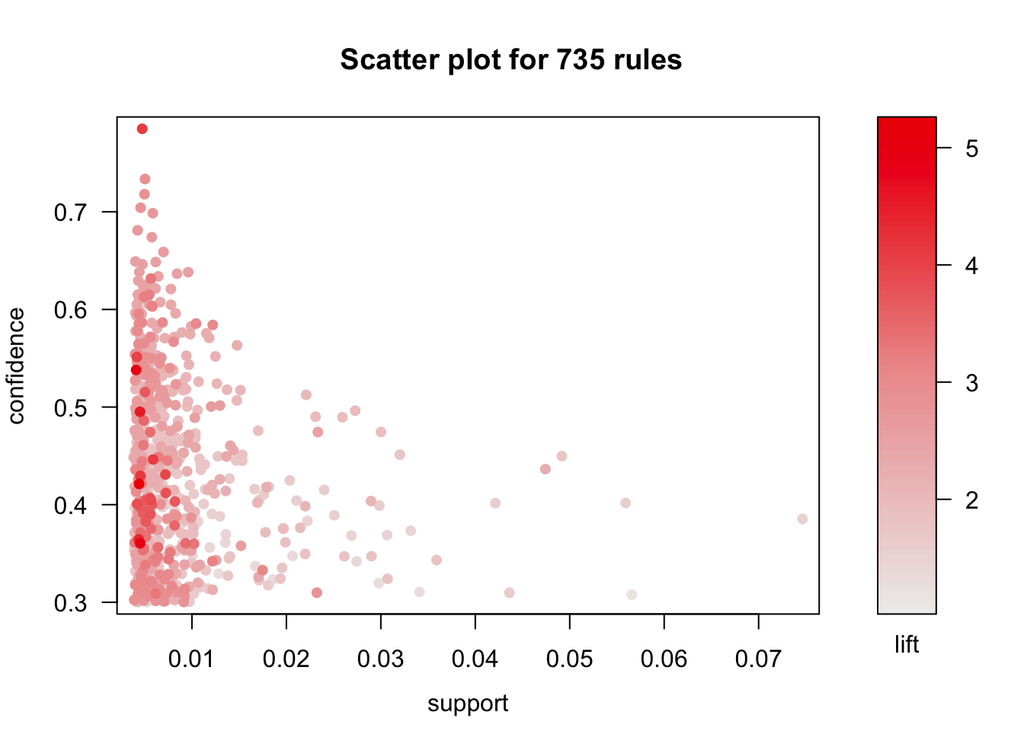

```r
plot(rules)
```

```r
inspect(sort(rules, by="support"))
```

```
##       lhs                           rhs                      support confidence     lift count
## [1]   {other vegetables}         => {whole milk}         0.074834774  0.3867578 1.513634   736
## [2]   {rolls/buns}               => {whole milk}         0.056634469  0.3079049 1.205032   557
## [3]   {yogurt}                   => {whole milk}         0.056024403  0.4016035 1.571735   551
## [4]   {root vegetables}          => {whole milk}         0.048906965  0.4486940 1.756031   481
## [5]   {root vegetables}          => {other vegetables}   0.047381800  0.4347015 2.246605   466
## [6]   {yogurt}                   => {other vegetables}   0.043416370  0.3112245 1.608457   427
## [7]   {tropical fruit}           => {whole milk}         0.042297916  0.4031008 1.577595   416
## [8]   {tropical fruit}           => {other vegetables}   0.035892222  0.3420543 1.767790   353
## [9]   {bottled water}            => {whole milk}         0.034367056  0.3109476 1.216940   338
## [10]  {pastry}                   => {whole milk}         0.033248602  0.3737143 1.462587   327
## [11]  {whipped/sour cream}       => {whole milk}         0.032231825  0.4496454 1.759754   317
## [12]  {sausage}                  => {rolls/buns}         0.030604982  0.3257576 1.771048   301
## [13]  {citrus fruit}             => {whole milk}         0.030503305  0.3685504 1.442377   300
## [14]  {pip fruit}                => {whole milk}         0.030096594  0.3978495 1.557043   296
## [15]  {domestic eggs}            => {whole milk}         0.029994916  0.4727564 1.850203   295
## [16]  {sausage}                  => {whole milk}         0.029893238  0.3181818 1.245252   294
## [17]  {whipped/sour cream}       => {other vegetables}   0.028876462  0.4028369 2.081924   284
## [18]  {citrus fruit}             => {other vegetables}   0.028876462  0.3488943 1.803140   284
## [19]  {butter}                   => {whole milk}         0.027554652  0.4972477 1.946053   271
## [20]  {newspapers}               => {whole milk}         0.027351296  0.3426752 1.341110   269
## [21]  {fruit/vegetable juice}    => {whole milk}         0.026639553  0.3684951 1.442160   262
## [22]  {curd}                     => {whole milk}         0.026131164  0.4904580 1.919481   257
## [23]  {pip fruit}                => {other vegetables}   0.026131164  0.3454301 1.785237   257
## [24]  {brown bread}              => {whole milk}         0.025216065  0.3887147 1.521293   248
## [25]  {margarine}                => {whole milk}         0.024199288  0.4131944 1.617098   238
## [26]  {root vegetables,
##        other vegetables}         => {whole milk}         0.023182511  0.4892704 1.914833   228
## [27]  {root vegetables,
##        whole milk}               => {other vegetables}   0.023182511  0.4740125 2.449770   228
## [28]  {other vegetables,
##        whole milk}               => {root vegetables}    0.023182511  0.3097826 2.842082   228
## [29]  {domestic eggs}            => {other vegetables}   0.022267412  0.3509615 1.813824   219
## [30]  {other vegetables,
##        yogurt}                   => {whole milk}         0.022267412  0.5128806 2.007235   219
## [31]  {whole milk,
##        yogurt}                   => {other vegetables}   0.022267412  0.3974592 2.054131   219
## [32]  {pork}                     => {whole milk}         0.022165735  0.3844797 1.504719   218
## [33]  {pork}                     => {other vegetables}   0.021657346  0.3756614 1.941476   213
## [34]  {beef}                     => {whole milk}         0.021250635  0.4050388 1.585180   209
```

[output cut: 1393 more lines]

```
## [731] {other vegetables,
##        yogurt,
##        pastry}                   => {whole milk}         0.004067107  0.6153846 2.408399    40
## [732] {whole milk,
##        yogurt,
##        pastry}                   => {other vegetables}   0.004067107  0.4444444 2.296958    40
## [733] {other vegetables,
##        whole milk,
##        pastry}                   => {yogurt}             0.004067107  0.3846154 2.757064    40
## [734] {tropical fruit,
##        other vegetables,
##        rolls/buns}               => {whole milk}         0.004067107  0.5194805 2.033064    40
## [735] {tropical fruit,
##        whole milk,
##        rolls/buns}               => {other vegetables}   0.004067107  0.3703704 1.914132    40
```